# Practical Machine Learning

Tom Bruning

September 24, 2015

## Executive Summary

Using devices such as Jawbone Up, Nike FuelBand, and Fitbit it is now possible to collect a large amount of data about personal activity relatively inexpensively. These type of devices are part of the quantified self movement – a group of enthusiasts who take measurements about themselves regularly to improve their health, to find patterns in their behavior, or because they are tech geeks. One thing that people regularly do is quantify how much of a particular activity they do, but they rarely quantify how well they do it. In this project, my goal will be to use data from accelerometers on the belt, forearm, arm, and dumbell of 6 participants. They were asked to perform barbell lifts correctly and incorrectly in 5 different ways. More information is available from the website here: http://groupware.les.inf.puc-rio.br/har (see the section on the Weight Lifting Exercise Dataset).

I chose the gbm package to fit boosted trees to the training dataset. I used 10 fold cross validation three times to complete the model.

From the plot and table in Appendix I you can see the most important variables in determining which classe a particular activity is associated with are: **roll_belt** and **pitch_for3arm**. The accuracy (.97) associated with this model attests to the merits of using this method.

## The Model

### Setup

```r
# Download training dataset

fileUrl <- "https://d396qusza40orc.cloudfront.net/predmachlearn/pml-training.csv"
if(!file.exists("./pml-training.csv")) {
download.file(url = fileUrl_test, method = "curl", destfile = "./pml-training.csv")
}
df <- read.csv("pml-training.csv", header = TRUE)

# Load Packages
library(doMC)
  registerDoMC(cores = 2)
library(caret)
require(knitr)
require(gbm)
require(plyr)
set.seed(99)

# Clean the data getting rid of unnecessary columns,including variables that have NA's, zero values and near zero variances.  This took the total predictive variables to 52, with one predicted variable.

df_new <- df[-(1:7)]
nzvCol <- nearZeroVar(df_new)
df_new <- df_new[,-nzvCol]
df_new[df_new==""] <- NA
df_train <- df_new[ , colSums(is.na(df_new)) == 0]

# Partition the dataset into a training and a testing dataset

inTraining <- createDataPartition(y=df_train$classe, p=0.60, list=FALSE)
training <- df_train[ inTraining,]
testing  <- df_train[-inTraining,]
```

### Training Function

```r
fitControl <- trainControl(## 10-fold CV
    method = "repeatedcv",
    number = 10,
    ## repeated three times
    repeats = 3)

modelGbm <- train(classe ~ ., method="gbm",
                  data=training,
                  trControl=fitControl, verbose = FALSE)
modelGbm
```

```
## Stochastic Gradient Boosting
##
## 11776 samples
##    52 predictors
##     5 classes: 'A', 'B', 'C', 'D', 'E'
##
## No pre-processing
## Resampling: Cross-Validated (10 fold, repeated 3 times)
## Summary of sample sizes: 10598, 10597, 10600, 10598, 10598, 10598, ...
## Resampling results across tuning parameters:
##
##   interaction.depth  n.trees  Accuracy   Kappa      Accuracy SD
##   1                   50      0.7478230  0.6800314  0.011489113
##   1                  100      0.8156416  0.7665872  0.010323054
##   1                  150      0.8502895  0.8105272  0.008685099
##   2                   50      0.8520143  0.8124124  0.009348588
##   2                  100      0.9056559  0.8805904  0.008730501
##   2                  150      0.9323477  0.9143979  0.006840953
##   3                   50      0.8951824  0.8672409  0.008667264
##   3                  100      0.9424247  0.9271474  0.006766965
##   3                  150      0.9617856  0.9516547  0.004036438
##   Kappa SD
##   0.014617278
##   0.013041593
##   0.010961517
##   0.011890604
##   0.011058192
##   0.008654223
##   0.010998820
##   0.008572009
##   0.005110402
##
## Tuning parameter 'shrinkage' was held constant at a value of 0.1
##
## Tuning parameter 'n.minobsinnode' was held constant at a value of 10
## Accuracy was used to select the optimal model using  the largest value.
## The final values used for the model were n.trees = 150,
##  interaction.depth = 3, shrinkage = 0.1 and n.minobsinnode = 10.
```

```r
# Create confusion matrices for the training and test datasets, as well as the out of sample error rate.
gbm_confmat1 <- confusionMatrix(training$classe, predict(modelGbm, newdata=training))

gbm_confmat2 <- confusionMatrix(testing$classe, predict(modelGbm, newdata=testing))

oos <- round(1 - gbm_confmat1$overall[1], 2)
```

The following tables show the confusion matrix for both the training set and the testing set.

```r
kable(gbm_confmat1$table, format = "html", caption = "Training Data Confusion Matrix")
```

Training Data Confusion Matrix

|  | A | B | C | D | E |
| --- | --- | --- | --- | --- | --- |
| A | 3314 | 26 | 4 | 3 | 1 |
| B | 40 | 2196 | 41 | 1 | 1 |
| C | 0 | 35 | 1999 | 16 | 4 |
| D | 1 | 5 | 48 | 1864 | 12 |
| E | 3 | 17 | 11 | 26 | 2108 |

```r
kable(gbm_confmat2$table, format = "html", caption = "Testing Data Confusion Matrix")
```

Testing Data Confusion Matrix

|  | A | B | C | D | E |
| --- | --- | --- | --- | --- | --- |
| A | 2193 | 28 | 7 | 3 | 1 |
| B | 47 | 1429 | 40 | 1 | 1 |
| C | 0 | 48 | 1304 | 13 | 3 |
| D | 2 | 9 | 47 | 1217 | 11 |
| E | 2 | 16 | 10 | 18 | 1396 |

```r
# Download and load the testing dataset for the submission.

fileUrl_test <- "https://d396qusza40orc.cloudfront.net/predmachlearn/pml-testing.csv"
if(!file.exists("./pml-testing.csv")) {
download.file(url = fileUrl_test, method = "curl", destfile = "./pml-testing.csv")
}
df_test <- read.csv("pml-testing.csv", header = TRUE)
```

## Appendix I

### Create files for submission

```r
# From submission instructions:
answers <- predict(modelGbm, newdata=df_test)
pml_write_files = function(x){
    n = length(x)
    for(i in 1:n){
      filename = paste0("problem_id_",i,".txt")
      write.table(x[i],file=filename,quote=FALSE,row.names=FALSE,col.names=FALSE)
    }
}
pml_write_files(answers)
```

### Summary of Model

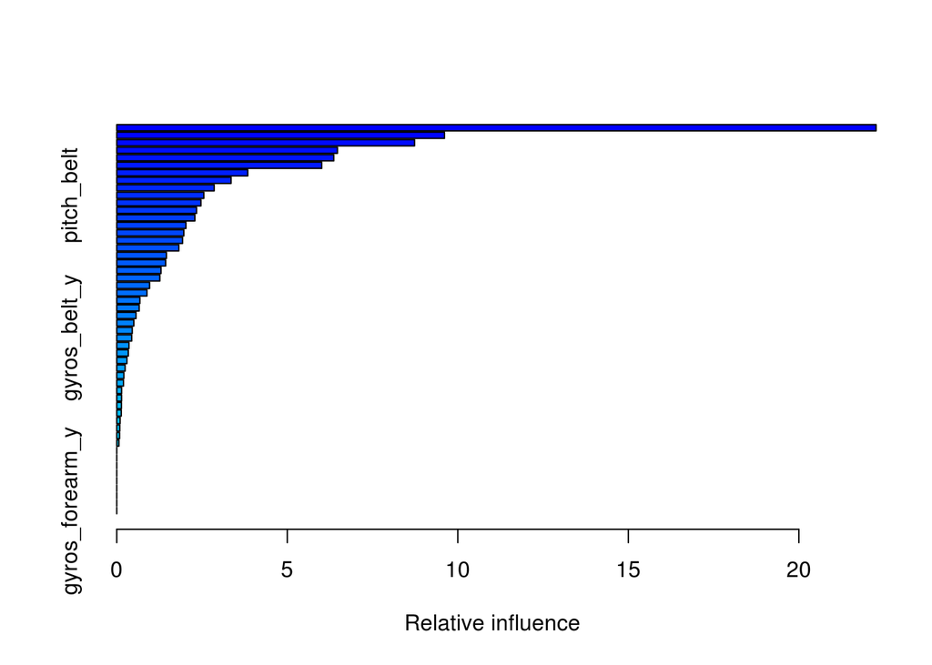

```
##                                       var     rel.inf
## roll_belt                       roll_belt 22.26292517
## pitch_forearm               pitch_forearm  9.60876271
## yaw_belt                         yaw_belt  8.73100578
## magnet_dumbbell_y       magnet_dumbbell_y  6.47001643
## magnet_dumbbell_z       magnet_dumbbell_z  6.36305594
## roll_forearm                 roll_forearm  6.00934846
## magnet_belt_z               magnet_belt_z  3.84092701
## accel_dumbbell_y         accel_dumbbell_y  3.35225992
## gyros_belt_z                 gyros_belt_z  2.85574219
## pitch_belt                     pitch_belt  2.55173845
## accel_forearm_x           accel_forearm_x  2.46720448
## accel_forearm_z           accel_forearm_z  2.33959301
## magnet_forearm_z         magnet_forearm_z  2.28952299
## yaw_arm                           yaw_arm  2.02848948
## roll_dumbbell               roll_dumbbell  1.96593785
## gyros_dumbbell_y         gyros_dumbbell_y  1.92901734
## accel_dumbbell_x         accel_dumbbell_x  1.82015791
## accel_dumbbell_z         accel_dumbbell_z  1.45517186
## magnet_dumbbell_x       magnet_dumbbell_x  1.43310991
## magnet_arm_z                 magnet_arm_z  1.29811937
## magnet_belt_y               magnet_belt_y  1.26299764
## roll_arm                         roll_arm  0.96188841
## magnet_belt_x               magnet_belt_x  0.88506059
## magnet_arm_x                 magnet_arm_x  0.67753472
## magnet_forearm_x         magnet_forearm_x  0.65677038
## accel_belt_z                 accel_belt_z  0.56474092
## total_accel_dumbbell total_accel_dumbbell  0.49937201
## gyros_arm_y                   gyros_arm_y  0.45314429
## gyros_belt_y                 gyros_belt_y  0.43742202
## total_accel_forearm   total_accel_forearm  0.35762358
## gyros_dumbbell_z         gyros_dumbbell_z  0.33828761
## magnet_arm_y                 magnet_arm_y  0.29850233
## accel_arm_y                   accel_arm_y  0.24490196
## magnet_forearm_y         magnet_forearm_y  0.20807379
## accel_arm_x                   accel_arm_x  0.19693780
## accel_forearm_y           accel_forearm_y  0.14213870
## yaw_dumbbell                 yaw_dumbbell  0.14108908
## gyros_arm_x                   gyros_arm_x  0.13734021
## gyros_forearm_z           gyros_forearm_z  0.13159049
## accel_arm_z                   accel_arm_z  0.09902781
## gyros_dumbbell_x         gyros_dumbbell_x  0.08808731
## pitch_dumbbell             pitch_dumbbell  0.08243539
## gyros_belt_x                 gyros_belt_x  0.06292669
## total_accel_belt         total_accel_belt  0.00000000
## accel_belt_x                 accel_belt_x  0.00000000
## accel_belt_y                 accel_belt_y  0.00000000
## pitch_arm                       pitch_arm  0.00000000
## total_accel_arm           total_accel_arm  0.00000000
## gyros_arm_z                   gyros_arm_z  0.00000000
## yaw_forearm                   yaw_forearm  0.00000000
## gyros_forearm_x           gyros_forearm_x  0.00000000
## gyros_forearm_y           gyros_forearm_y  0.00000000
```

```r
summary(modelGbm)
```